# Cluster Analysis

WDI Indicators (sorry but the term ‘WDI Indicator’ is wrong WDI itself stands for World Development Indicators so ‘WDI Indicator’ means ‘World Development Indicators Indicator’ which is wrong)

Aryan Tajmirriahi

2018-07-21 23:55:19

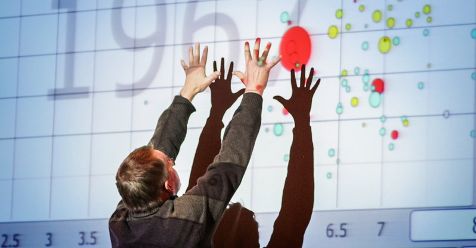

> با توجه به داده بانک جهانی به سوالات زیر پاسخ دهید. برای استفاده از داده از سه فایل زیر استفاده نمایید. داده نام کشورها: WDICountry داده نام سری های زمانی: WDISeries داده کل: WDIData در صورتی که داده را در اختیار ندارید می توانید از بسته WDI استفاده نموده و داده های مورد نظر را استخراج نمایید.

لطفا در ابتدا کد زیر را برای آماده سازی داده اجرا کنید.

```r
library(WDI)
library(dplyr)
```

```r
library(highcharter)
library(ggplot2)
library(stats)
library(tidyr)
library(countrycode)
library(h2o)
data = read.csv("E:\\edu\\TahlilDade\\data\\WDIDATA.csv")
data %>%
  gather(str_year, measure, -Country.Code, -Indicator.Name, -Indicator.Code, -`ï..Country.Name`)%>%
  mutate(year=as.integer(substr(str_year, 2, 5))) -> data1
data1 %>%
  select(-Indicator.Name) %>%
  spread(Indicator.Code, measure) %>%
  rename(country = `ï..Country.Name`, iso2c=Country.Code)-> data2
```

۱. ده کشور فقیر دنیا را بیابید. نمودار درآمد روزانه آنها را رسم کنید. چند درصد از اعضای این کشورها زیر خط فقر هستند؟ متوسط عمر در این کشورها چقدر است؟

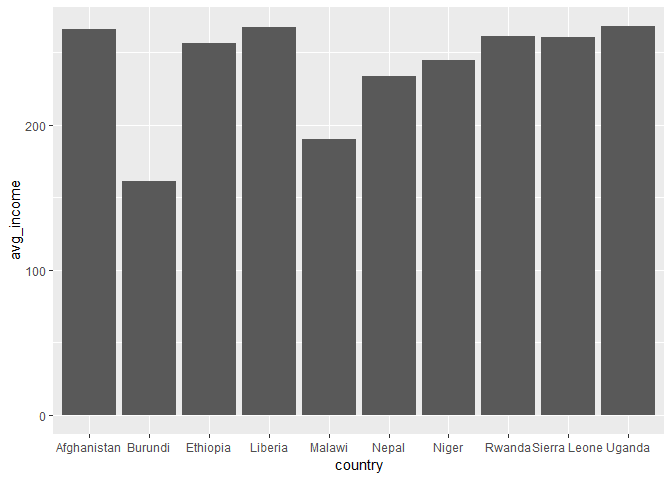

```r
data2 %>%
  select(poverty_rat = 'SI.POV.NAHC', income = NY.GDP.PCAP.CD, country, life_exp=SP.DYN.LE00.IN, iso2c, year) -> data_q1

data_q1%>%
  group_by(iso2c, country) %>%
  summarise(avg_pov_rat = mean(poverty_rat, na.rm = TRUE), avg_income = mean(income, na.rm = TRUE), avg_life_exp = mean(life_exp, na.rm = TRUE)) %>%
  ungroup() %>%
  arrange(avg_income) %>%
  slice(1:10) -> data_q1_1
data_q1_1 %>% View()
ggplot(data_q1_1, aes(x = country, y = avg_income)) + geom_col()
```

۲. تراژدی روآندا: بر اساس داده های امید به زندگی ابتدا نمودار سالانه نمودار جعبه ایی امید به زندگی کشورها را رسم نمایید(در یک نمودار!). سپس سری زمانی امید به زندگی روآندا را به آن اضافه کنید. چه می بینید؟ چند میلیون نفر کشته شدند؟

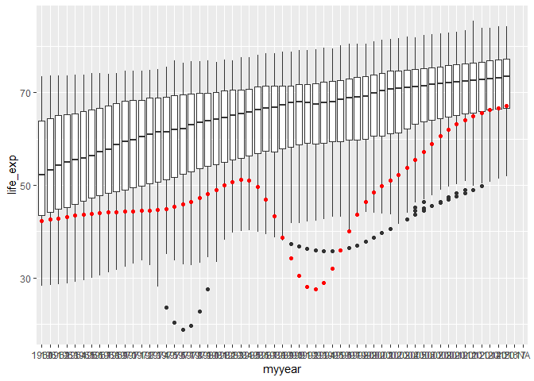

```r
data2 %>%
  select(life_exp = SP.DYN.LE00.IN, country, iso2c, year) -> data_q2
data_q2$myyear = paste("", data_q2$year)
data_q2$is_rwanda = data_q2$country == "Rwanda"
ggplot(data=data_q2, aes(x=myyear, y=life_exp)) + geom_boxplot() + geom_point(data = data_q2 %>% filter(country=="Rwanda"), color="red")
```

```r
data_q2 %>% View()
data2 %>%
  select(population = SP.POP.TOTL, country, iso2c, year) %>%
  filter(country == 'Rwanda') %>%
  .[complete.cases(.),] -> data_q2_2

data_q2_2 %>% lm(population~year, data = .) -> fit
data_q2_2 %>% cbind(predict.lm(fit, .),.) %>% View
```

۳. نمودار امید به زندگی و هزینه های بهداشتی را رسم کنید. چه نتیجه ایی می گیرید؟

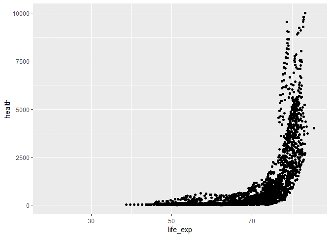

```r
data2 %>%
  select(life_exp = SP.DYN.LE00.IN, health=SH.XPD.CHEX.PC.CD, country, iso2c, year) ->data_q3
ggplot(data=data_q3, aes(x = life_exp, y=health)) + geom_point()
```

۴. آیا قدرت خرید خانواده های ایرانی در ۵۰ سال اخیر افزایش یافته است؟ برای این کار از داده های اقتصادی خانوار استفاده کنید.

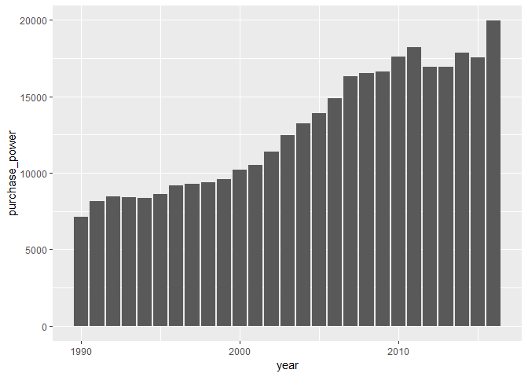

```r
data2 %>%
  filter(iso2c=="IRN") %>%
  select(country, iso2c, year, purchase_power = NY.GDP.PCAP.PP.CD)  ->data_q4
ggplot(data_q4, aes(x=year, y=purchase_power)) + geom_col()
```

۵. رشد اقتصادی ایران را با کشورهای دیگر در طول ۲۰ سال گذشته بر حسب بیست شاخص های اقتصادی مهم مانند تولید ناخالص ملی، تورم و … ارزیابی کنید! (برای هر شاخص از تصویرسازی استفاده کنید.)

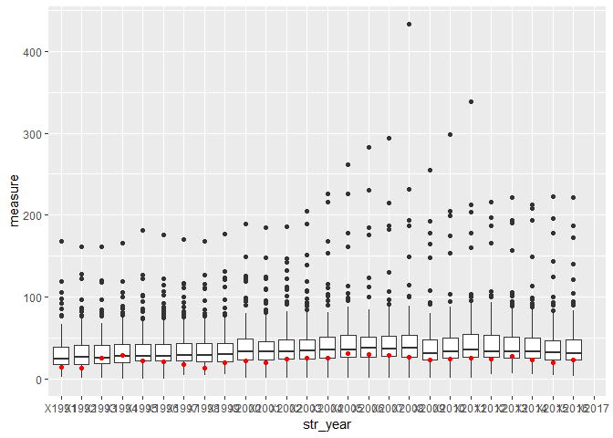

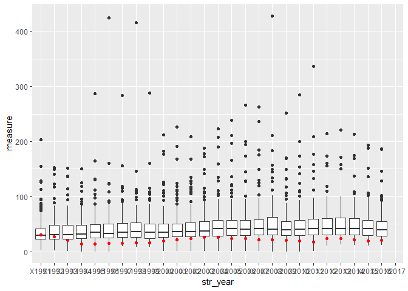

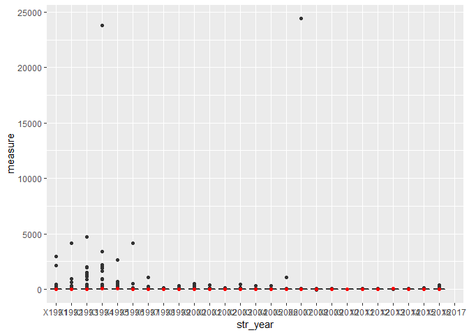

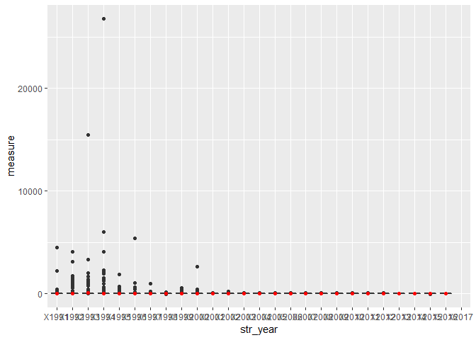

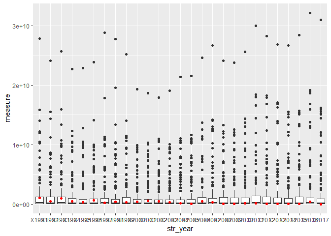

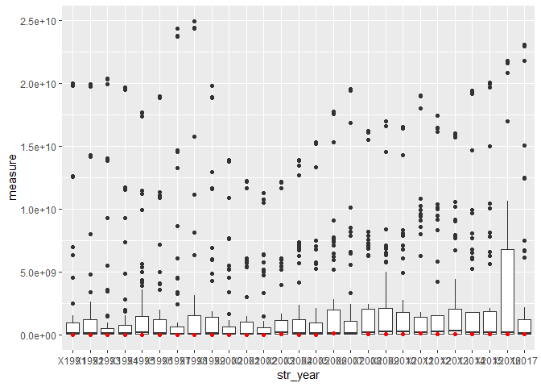

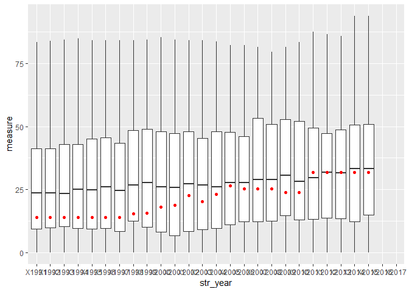

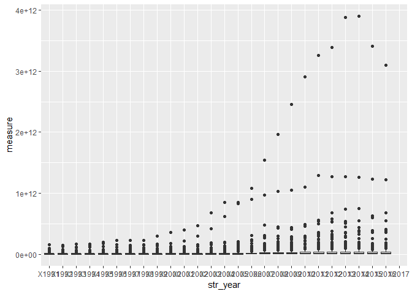

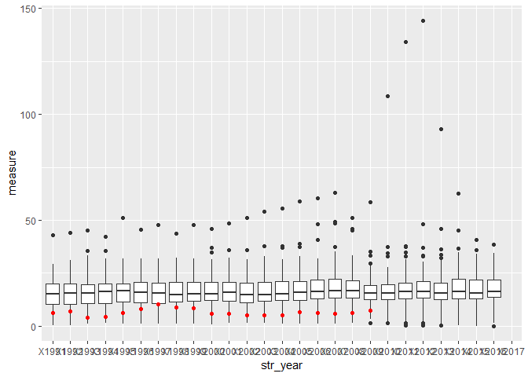

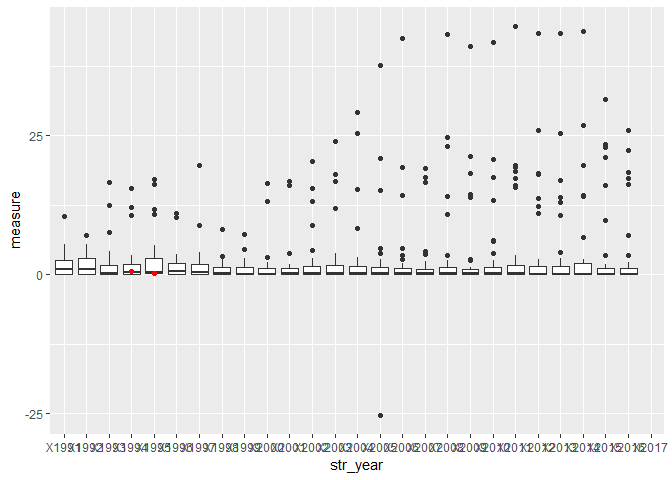

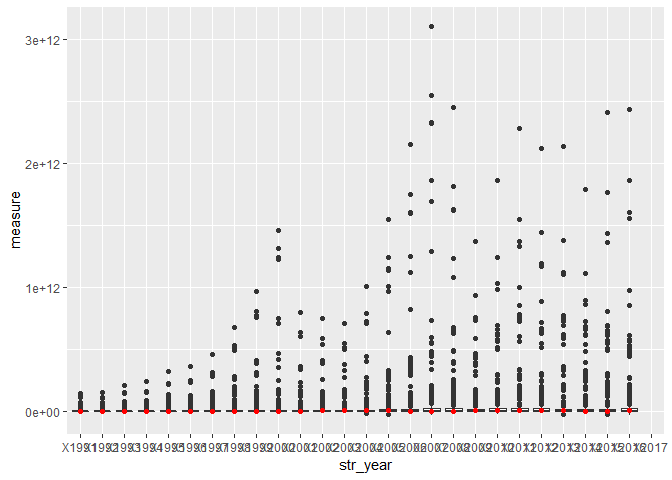

[figure not shown]

[10 more figures not shown]

```r
economic_indicators = c('NE.EXP.GNFS.ZS', 'NE.IMP.GNFS.ZS', 'FP.CPI.TOTL.ZG', 'NY.GDP.DEFL.KD.ZG',
                        'MS.MIL.MPRT.KD', 'MS.MIL.XPRT.KD', 'TX.MNF.TECH.ZS.UN', 'FI.RES.TOTL.CD',
                        'GC.TAX.TOTL.GD.ZS', 'GC.TAX.EXPT.ZS', 'BX.KLT.DINV.CD.WD', 'BX.KLT.DINV.WD.GD',
                        'NY.GDP.MKTP.KD.ZG', 'SI.POV.GAPS', 'SI.POV.LMIC.GP',
                        'SI.POV.UMIC.GP', 'BN.CAB.XOKA.GD.ZS', 'NV.AGR.TOTL.ZS', 'SH.XPD.CHEX.GD.ZS',
                        'GC.DOD.TOTL.GD.ZS', 'SE.XPD.PRIM.PC.ZS', 'NV.IND.TOTL.ZS') #tanks to MohammadMehdi Faryabi


gdp_growth = c(
  "NY.GDP.MKTP.KD.ZG" #GDP growth (annual %)
)

for(indicator in economic_indicators){
  print(
    data1 %>%
      filter(year > 1990) %>%
      filter(Indicator.Code==indicator) %>%
      ggplot(data=., aes(x=str_year, y=measure)) + geom_boxplot() + geom_point(data = . %>% filter(Country.Code=='IRN'), aes(x=str_year, y=measure), color = 'red')
  )
}
```

۶. در قسمت قبل با استفاده از روش خوشه بندی k-means داده ها را به سه دسته تقسیم کنید. ایران در کدام دسته می گنجد؟ (پیش از خوشه بندی طبیعتا داده را باید پاکسازی و استاندارد سازی نمایید.)

```r
data1 %>%
  select(-Indicator.Name) %>%
  rename(country = `ï..Country.Name`, iso2c=Country.Code) %>%
  group_by(iso2c, country, Indicator.Code) %>%
  summarise(m_measure = mean(measure, na.rm = TRUE)) %>%
  filter(Indicator.Code %in% union(economic_indicators, gdp_growth)) %>%
  spread(Indicator.Code, m_measure)  -> data_q6


for(i in 3:(data_q6 %>% dim %>% .[2])){
  data_q6[,i] %>% .[complete.cases(.),] %>% unlist() %>% mean(na.rm = TRUE) -> k
  data_q6[,i] = ifelse(is.nan(data_q6[,i] %>% unlist()), k, data_q6[,i] %>% unlist())
  data_q6[,i] = (data_q6[,i] %>% unlist() - mean(data_q6[,i] %>% unlist())) / sd(data_q6[,i] %>% unlist())
}
data_q6 %>%
  ungroup() -> data_q6
data_q6 %>%
  select(-country, -iso2c) %>%
  kmeans(., centers = 3) %>%
  .$cluster -> data_q6$cluster

data_q6 %>%
  select(country, cluster) %>% View
```

۷. به وسیله تحلیل مولفه اصلی بعد داده رو به دو کاهش دهید سپس خوشه های به دست آمده در قسمت قبل را بر روی آن نمایش دهید. آیا عملکرد روش خوشه بندی شما مطلوب بوده است؟

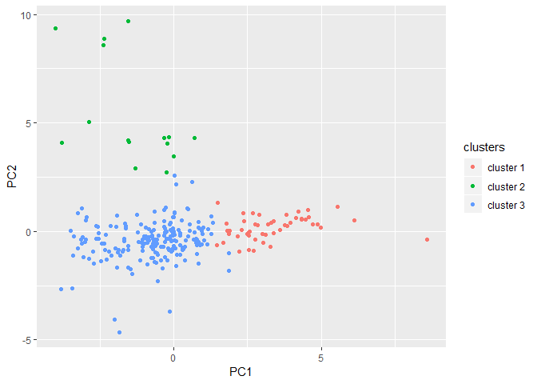

```r
pca <- prcomp(data_q6 %>% select(-country, -iso2c, -cluster))

pca$x %>%
  as.data.frame() %>%
  select(PC1, PC2) %>%
  cbind(data_q6$cluster) %>%
  mutate(clusters = paste("cluster", `data_q6$cluster`)) %>%
  ggplot(aes(x = PC1, y = PC2, color = clusters)) + geom_point()
```

۸. با استفاده از داده روشی برای پیش بینی رشد اقتصادی ایران در سال آینده ارائه دهید.

```r
data1 %>%
  select(-Indicator.Name) %>%
  rename(country = `ï..Country.Name`, iso2c=Country.Code) %>%
  filter(iso2c=="IRN") %>%
  filter(Indicator.Code %in% union(economic_indicators, gdp_growth)) %>%
  spread(Indicator.Code, measure) %>%
  select(-country, -iso2c, -str_year) -> data_q8

for(i in 2:(data_q8 %>% dim %>% .[2])){
  data_q8[,i] %>%  mean(na.rm = TRUE) -> k
  data_q8[,i] = ifelse(is.na(data_q8[,i]), k, data_q8[,i])
}
data_q8 %>%
  select(-GC.DOD.TOTL.GD.ZS) %>%
  .[complete.cases(.),]->data_q8
h2o.init()
```

[output not shown]

```r
data_q8 %>%
  as.h2o() %>%
  h2o.glm(y=gdp_growth, x=colnames(.), .)
```

```
## Model Details:
## ==============
##
## H2ORegressionModel: glm
## Model ID:  GLM_model_R_1532182231716_115
## GLM Model: summary
##     family     link                              regularization
## 1 gaussian identity Elastic Net (alpha = 0.5, lambda = 0.8777 )
##   number_of_predictors_total number_of_active_predictors
## 1                         20                          13
##   number_of_iterations              training_frame
## 1                    2 file59cc27104303_sid_bfea_2
##
## Coefficients: glm coefficients
##               names coefficients standardized_coefficients
## 1         Intercept    16.435797                  4.339040
## 2              year    -0.001385                 -0.023387
## 3 BN.CAB.XOKA.GD.ZS     0.389785                  1.226534
## 4 BX.KLT.DINV.CD.WD     0.000000                  0.000000
## 5    FI.RES.TOTL.CD    -0.000000                 -2.756197
##
## ---
##                names coefficients standardized_coefficients
## 16 SE.XPD.PRIM.PC.ZS     0.000000                  0.000000
## 17 SH.XPD.CHEX.GD.ZS    -0.301043                 -0.124960
## 18       SI.POV.GAPS     0.000000                  0.000000
## 19    SI.POV.LMIC.GP     0.000000                  0.000000
## 20    SI.POV.UMIC.GP     0.000000                  0.000000
## 21 TX.MNF.TECH.ZS.UN    -0.151376                 -0.682250
##
## H2ORegressionMetrics: glm
## ** Reported on training data. **
##
## MSE:  34.15499
## RMSE:  5.844227
## MAE:  4.242499
## RMSLE:  NaN
## Mean Residual Deviance :  34.15499
## R^2 :  0.4913026
## Null Deviance :3894.239
## Null D.o.F. :57
## Residual Deviance :1980.989
## Residual D.o.F. :44
## AIC :399.3896
```

۹. سوالهای ۵ تا ۷ را ابتدا برای ۲۰ شاخص سلامت سپس بر حسب ۲۰ شاخص آموزشی تکرار کنید.

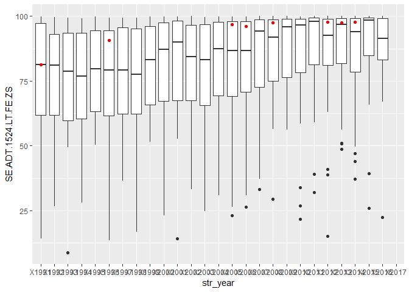

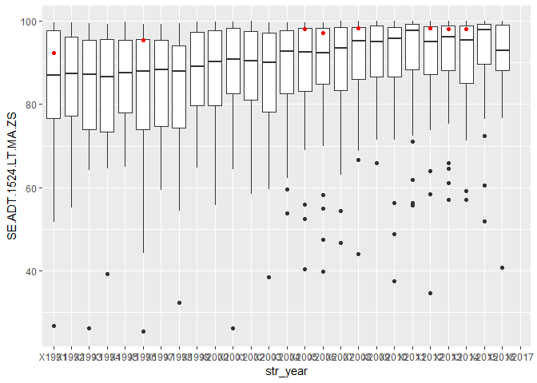

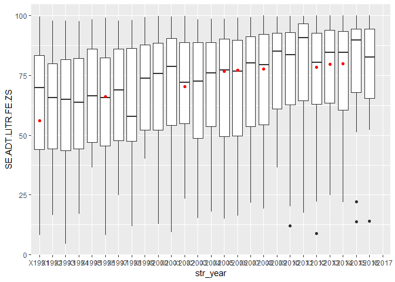

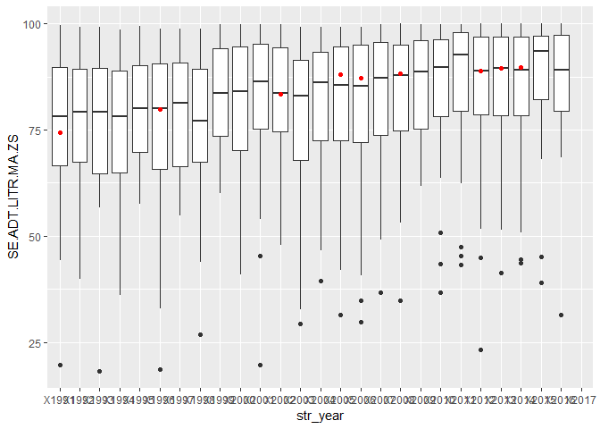

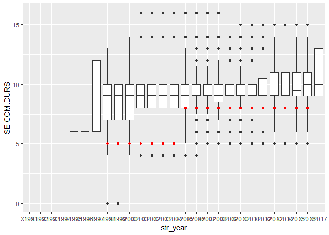

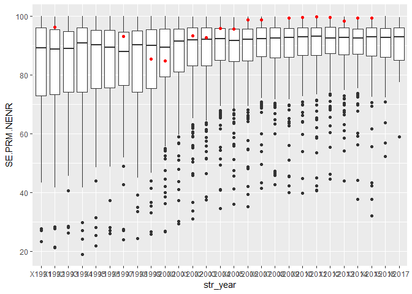

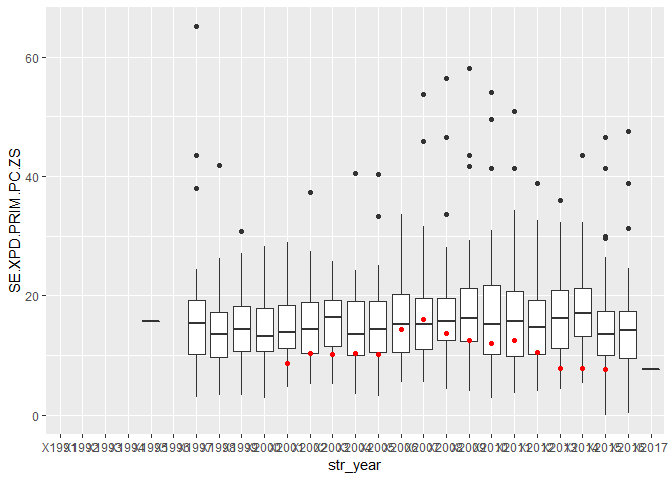

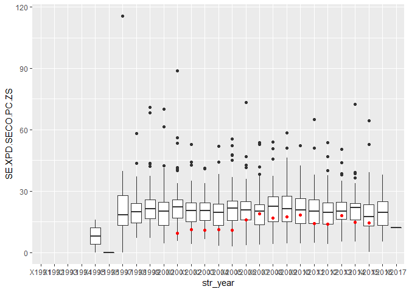

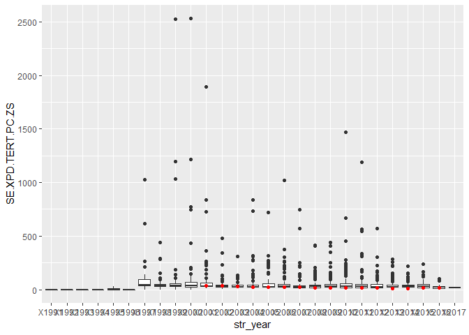

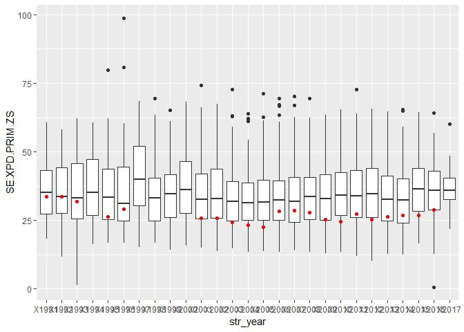

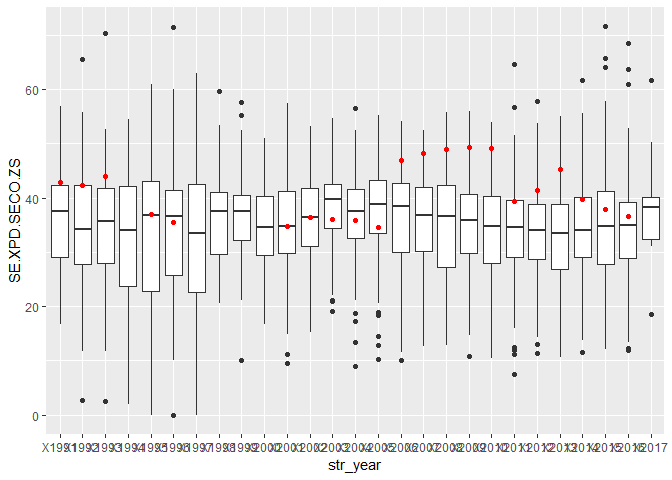

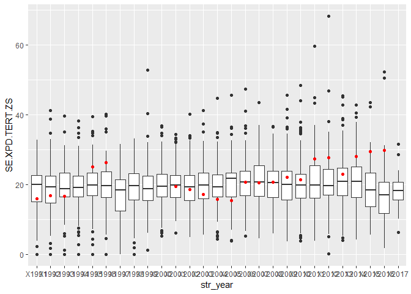

[8 more figures not shown]

```r
education_indicators = c('SE.ADT.1524.LT.FE.ZS', 'SE.ADT.1524.LT.MA.ZS', 'SE.ADT.LITR.FE.ZS', 'SE.ADT.LITR.MA.ZS',
                        'SE.COM.DURS', 'SE.PRM.NENR', 'SE.XPD.PRIM.PC.ZS', 'SE.XPD.SECO.PC.ZS',
                        'SE.XPD.TERT.PC.ZS', 'SE.XPD.PRIM.ZS', 'SE.XPD.SECO.ZS', 'SE.XPD.TERT.ZS',
                        'IP.JRN.ARTC.SC', 'GB.XPD.RSDV.GD.ZS', 'SE.PRE.ENRL.TC.ZS',
                        'SE.PRE.ENRR.FE', 'SE.PRE.ENRR.MA', 'SE.PRM.AGES', 'SE.PRM.CMPT.FE.ZS',
                        'SE.PRM.CMPT.MA.ZS') #tanks to MohammadMehdi Frayabi
for(indicator in education_indicators){
  print(
    data1 %>%
      filter(year > 1990) %>%
      filter(Indicator.Code==indicator) %>%
      ggplot(data=., aes(x=str_year, y=measure)) + geom_boxplot() + geom_point(data = . %>% filter(Country.Code=='IRN'), aes(x=str_year, y=measure), color = 'red') + ylab(indicator)
  )
}
```

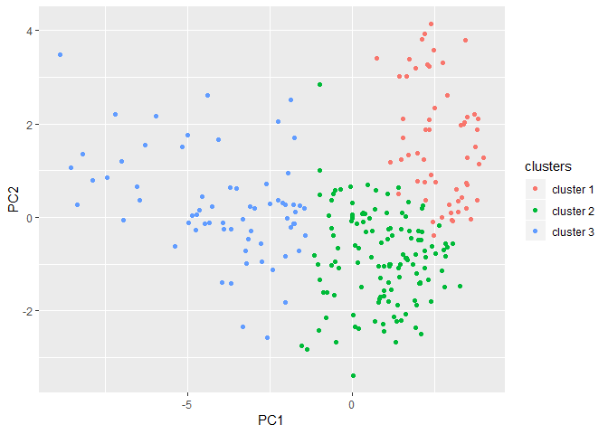

```r
data1 %>%
  select(-Indicator.Name) %>%
  rename(country = `ï..Country.Name`, iso2c=Country.Code) %>%
  group_by(iso2c, country, Indicator.Code) %>%
  summarise(m_measure = mean(measure, na.rm = TRUE)) %>%
  filter(Indicator.Code %in% education_indicators) %>%
  spread(Indicator.Code, m_measure)  -> data_q9_1


for(i in 3:(data_q9_1 %>% dim %>% .[2])){
  data_q9_1[,i] %>% .[complete.cases(.),] %>% unlist() %>% mean(na.rm = TRUE) -> k
  data_q9_1[,i] = ifelse(is.nan(data_q9_1[,i] %>% unlist()), k, data_q9_1[,i] %>% unlist())
  data_q9_1[,i] = (data_q9_1[,i] %>% unlist() - mean(data_q9_1[,i] %>% unlist())) / sd(data_q9_1[,i] %>% unlist())
}
data_q9_1 %>%
  ungroup() -> data_q9_1
data_q9_1 %>%
  select(-country, -iso2c) %>%
  kmeans(., centers = 3) %>%
  .$cluster -> data_q9_1$cluster

data_q9_1 %>%
  select(country, cluster) %>% View

pca <- prcomp(data_q9_1 %>% select(-country, -iso2c, -cluster))

pca$x %>%
  as.data.frame() %>%
  select(PC1, PC2) %>%
  cbind(data_q9_1$cluster) %>%
  mutate(clusters = paste("cluster", `data_q9_1$cluster`)) %>%
  ggplot(aes(x = PC1, y = PC2, color = clusters)) + geom_point()
```